# Chapter 7 Assignment

Joe Dickerson

2025-10-05

Problem 9.

1. Use the poly() function to fit a cubic polynomial regression to predict nox using dis. Report the regression output, and plot the resulting data and polynomial fits.

We see significance with each degree of polynomial, with dis having a coefficient of -2.003, dis^2 a coefficient of 0.856, and dis^3 a coefficient of -0.318. The plots appear as expected as the degree of polynomial increase.

```r
data(Boston)

fit <- lm(nox ~ poly(dis, 3), data = Boston)

summary(fit)
```

```
##
## Call:
## lm(formula = nox ~ poly(dis, 3), data = Boston)
##
## Residuals:
##       Min        1Q    Median        3Q       Max
## -0.121130 -0.040619 -0.009738  0.023385  0.194904
##
## Coefficients:
##                Estimate Std. Error t value Pr(>|t|)
## (Intercept)    0.554695   0.002759 201.021  < 2e-16 ***
## poly(dis, 3)1 -2.003096   0.062071 -32.271  < 2e-16 ***
## poly(dis, 3)2  0.856330   0.062071  13.796  < 2e-16 ***
## poly(dis, 3)3 -0.318049   0.062071  -5.124 4.27e-07 ***
## ---
## Signif. codes:  0 '***' 0.001 '**' 0.01 '*' 0.05 '.' 0.1 ' ' 1
##
## Residual standard error: 0.06207 on 502 degrees of freedom
## Multiple R-squared:  0.7148, Adjusted R-squared:  0.7131
## F-statistic: 419.3 on 3 and 502 DF,  p-value: < 2.2e-16
```

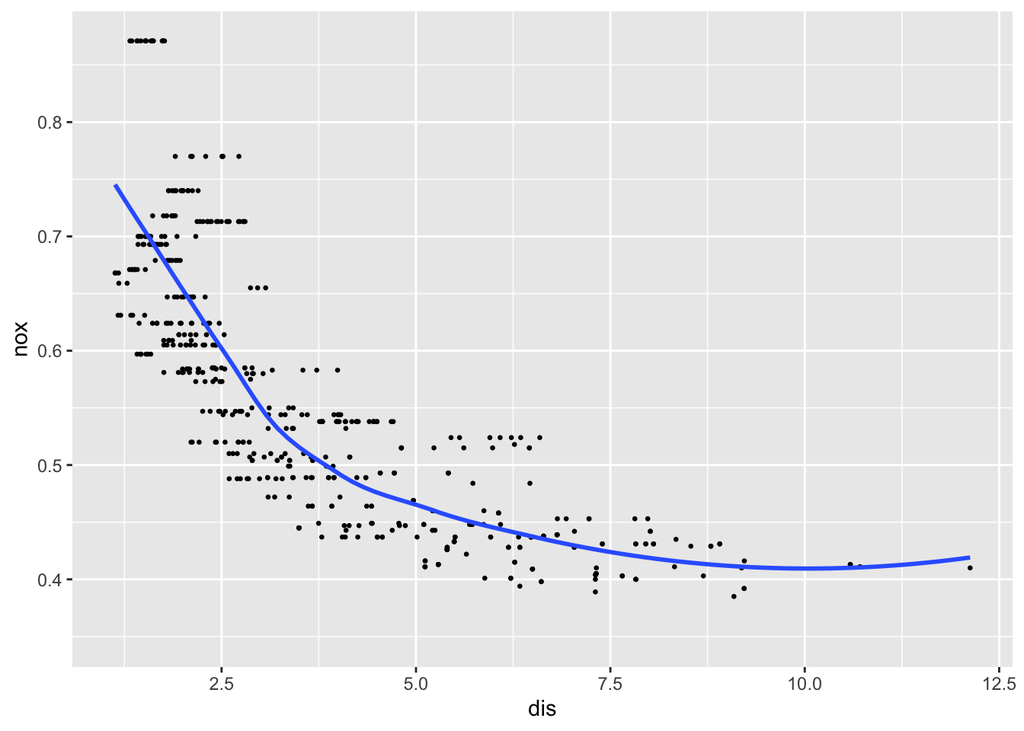

```r
## coef(summary(fit))

## plot(Boston$nox ~ Boston$dis)

Boston %>%
  ggplot(aes(x = dis, y = nox)) +
  geom_point(size = .5) +
  geom_smooth(fill = NA)
```

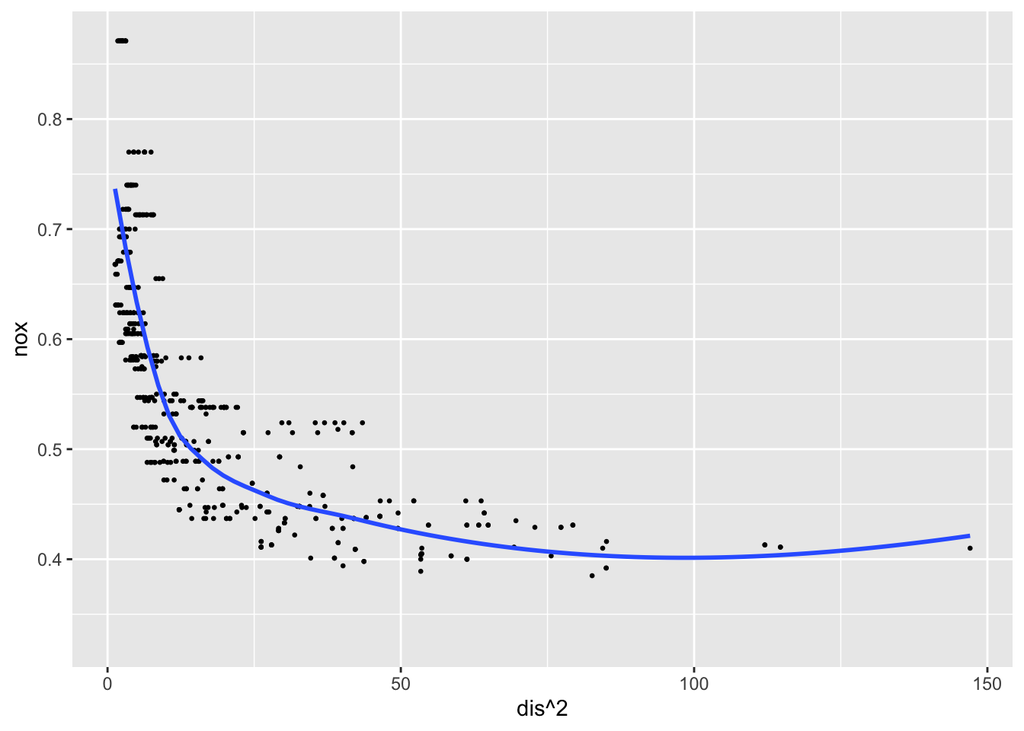

```r
Boston %>%
  ggplot(aes(x = dis^2, y = nox)) +
  geom_point(size = .5) +
  geom_smooth(fill = NA)
```

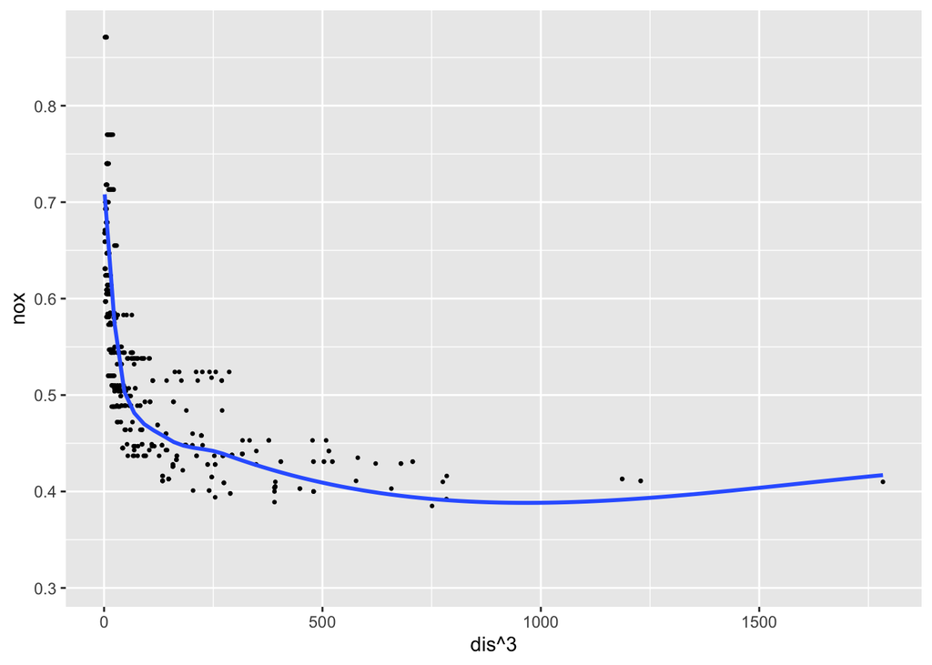

```r
Boston %>%
  ggplot(aes(x = dis^3, y = nox)) +
  geom_point(size = .5) +
  geom_smooth(fill = NA)
```

2. Plot the polynomial fits for a range of different polynomial degrees (say, from 1 to 10), and report the associated residual sum of squares.

The RSS for the model is 1.832. Interestingly, we lost significance at dis^4, but dis^5, dis^6, and dis^7 are significant. dis^8 is barely significant with a p-value of 0.0536, which would probably not be adequate for an analysis or interpretation. dis^9 and dis^10 are not statistically significant.

```r
fit2 <- lm(nox ~ poly(dis, 10), data = Boston)

sum(resid(fit2)^2)
```

```
## [1] 1.832171
```

3. Perform cross-validation or another approach to select the optimal degree for the polynomial, and explain your results.

An ANOVA is performed to compare models, and it appears that a cubic model is the best approach as the fourth degree polynomial model loses statistical significance. These results are similar to what was found in part b.

```r
fit.1 <- lm(nox ~ dis, data = Boston)
fit.2 <- lm(nox ~ poly(dis, 2), data = Boston)
fit.3 <- lm(nox ~ poly(dis, 3), data = Boston)
fit.4 <- lm(nox ~ poly(dis, 4), data = Boston)
fit.5 <- lm(nox ~ poly(dis, 5), data = Boston)
fit.6 <- lm(nox ~ poly(dis, 6), data = Boston)
fit.7 <- lm(nox ~ poly(dis, 7), data = Boston)
fit.8 <- lm(nox ~ poly(dis, 8), data = Boston)
fit.9 <- lm(nox ~ poly(dis, 9), data = Boston)
fit.10 <- lm(nox ~ poly(dis, 10), data = Boston)

anova(fit.1, fit.2, fit.3, fit.4, fit.5, fit.6, fit.7, fit.8, fit.9, fit.10)
```

```
## Analysis of Variance Table
##
## Model  1: nox ~ dis
## Model  2: nox ~ poly(dis, 2)
## Model  3: nox ~ poly(dis, 3)
## Model  4: nox ~ poly(dis, 4)
## Model  5: nox ~ poly(dis, 5)
## Model  6: nox ~ poly(dis, 6)
## Model  7: nox ~ poly(dis, 7)
## Model  8: nox ~ poly(dis, 8)
## Model  9: nox ~ poly(dis, 9)
## Model 10: nox ~ poly(dis, 10)
##    Res.Df    RSS Df Sum of Sq        F    Pr(>F)
## 1     504 2.7686
## 2     503 2.0353  1   0.73330 198.1169 < 2.2e-16 ***
## 3     502 1.9341  1   0.10116  27.3292 2.535e-07 ***
## 4     501 1.9330  1   0.00113   0.3040  0.581606
## 5     500 1.9153  1   0.01769   4.7797  0.029265 *
## 6     499 1.8783  1   0.03703  10.0052  0.001657 **
## 7     498 1.8495  1   0.02877   7.7738  0.005505 **
## 8     497 1.8356  1   0.01385   3.7429  0.053601 .
## 9     496 1.8333  1   0.00230   0.6211  0.431019
## 10    495 1.8322  1   0.00116   0.3133  0.575908
## ---
## Signif. codes:  0 '***' 0.001 '**' 0.01 '*' 0.05 '.' 0.1 ' ' 1
```

4. Use the bs () function to fit a regression spline to predict nox using dis. Report the output for the fit using four degrees of freedom. How did you choose the knots? Plot the resulting fit.

```r
library(splines)

attr(bs(Boston$dis, df = 4), "knots") ## 3.207450 knots
```

```
## [1] 3.20745
```

```r
spline.fit <- lm(nox ~ bs(dis, knots = 3.207450), data = Boston)
coef(spline.fit)
```

```
##               (Intercept) bs(dis, knots = 3.20745)1 bs(dis, knots = 3.20745)2
##                 0.7344739                -0.0580976                -0.4635635
## bs(dis, knots = 3.20745)3 bs(dis, knots = 3.20745)4
##                -0.1997882                -0.3888095
```

5. Now fit a regression spline for a range of degrees of freedom, and plot the resulting fits and report the resulting RSS. Describe the results obtained.

```r
attr(bs(Boston$dis, df=7), "knots")
```

```
## [1] 1.9512 2.6403 3.8750 5.6150
```

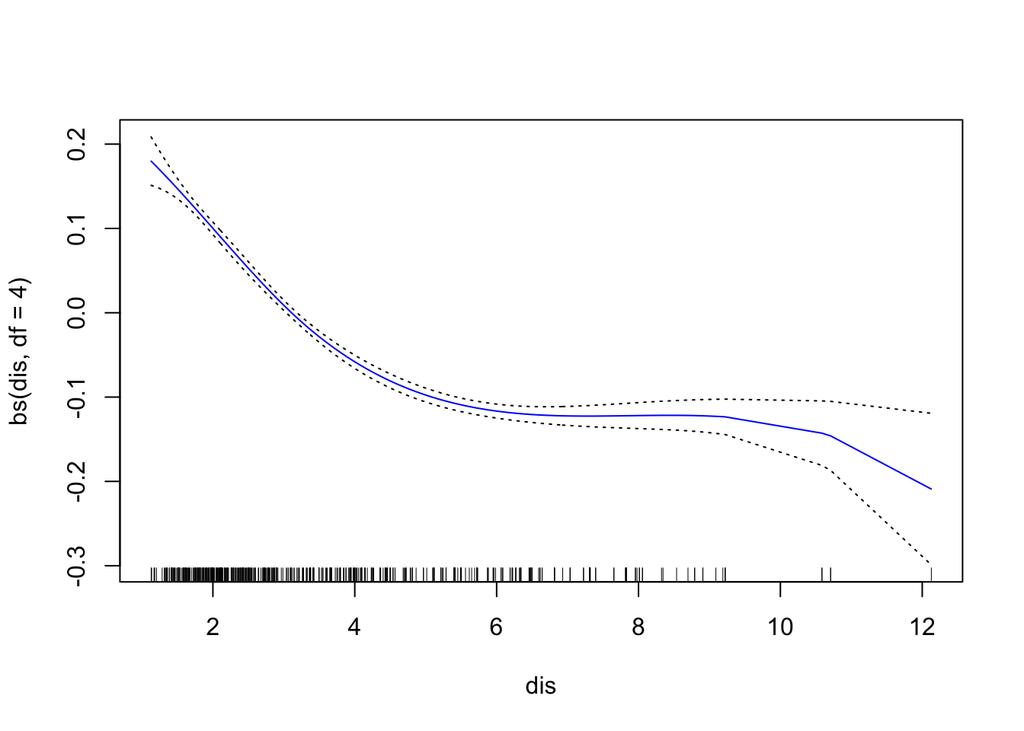

```r
spline.fit1 <- gam(nox ~ bs(dis, df = 4), data = Boston)
spline.fit2 <- gam(nox ~ bs(dis, df = 6), data = Boston)
spline.fit3 <- gam(nox ~ bs(dis, df = 8), data = Boston)
spline.fit4 <- gam(nox ~ bs(dis, df = 10), data = Boston)

plot(spline.fit1, se = TRUE, col = "blue")
```

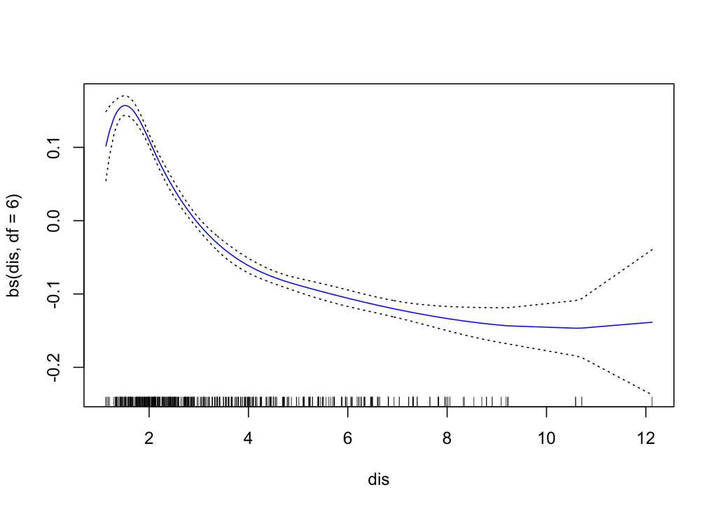

```r
plot(spline.fit2, se = TRUE, col = "blue")
```

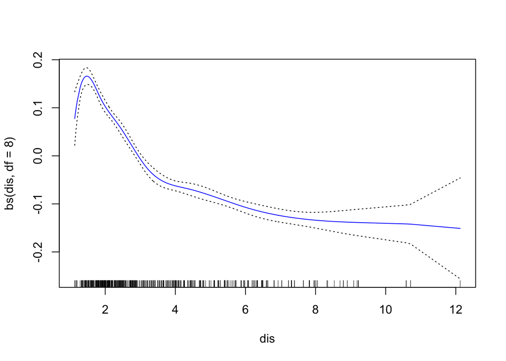

```r
plot(spline.fit3, se = TRUE, col = "blue")
```

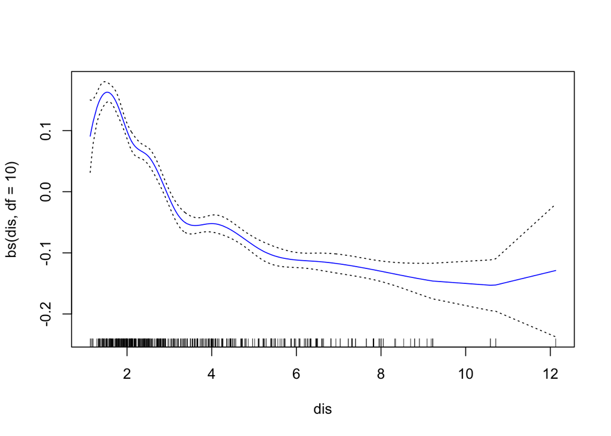

```r
plot(spline.fit4, se = TRUE, col = "blue")
```

```r
sum(residuals(spline.fit1)^2)
```

```
## [1] 1.922775
```

```r
sum(residuals(spline.fit2)^2)
```

```
## [1] 1.833966
```

```r
sum(residuals(spline.fit3)^2)
```

```
## [1] 1.816995
```

```r
sum(residuals(spline.fit4)^2)
```

```
## [1] 1.792535
```

```r
mean(Boston$dis)
```

```
## [1] 3.795043
```

6. Perform cross-validation or another approach in order to select the best degrees of freedom for a regression spline on this data. Describe your results.

We check the AIC values and it appears the spline.fit4 has the most appropriate degrees of freedom. However, based on the graphs from part e., there is a case to be made that the first fit with 4 degrees of freedom is most appropriate.

```r
c(AIC(spline.fit1), AIC(spline.fit2), AIC(spline.fit3), AIC(spline.fit4))
```

```
## [1] -1371.854 -1391.782 -1392.487 -1395.345
```

Problem 10.

1. Split the data into a training set and a test set. Using out-of-state tuition as the response and the other variables as the predictors, perform forward stepwise selection on the training set in order to identify a satisfactory model that uses just a subset of the predictors.

```r
data(College)
set.seed(123)


train1 <- sample(nrow(College) * 0.6)
train <- College[train1, ]
test <- College[-train1, ]

regfit.best <- regsubsets(Outstate ~ ., data = train, nvmax = ncol(College))

test.mat <- model.matrix(Outstate ~ ., data = test)

val.errors <- rep(NA, ncol(College))

for (i in 1:17) { ## 17 models in regfit.best
  coefi <- coef(regfit.best, id = i)
  pred <- test.mat[, names(coefi)] %*% coefi
  val.errors[i] <- mean((test$Outstate - pred)^2)
}

which.min(val.errors[-17])
```

```
## [1] 6
```

2. Fit a GAM on the training data, using out-of-state tuition as the response and the features selected in the previous step as the predictors. Plot the results, and explain your findings.

We see positive associations with all predictors.

```r
summary(regfit.best)
```

```
## Subset selection object
## Call: regsubsets.formula(Outstate ~ ., data = train, nvmax = ncol(College))
## 17 Variables  (and intercept)
##             Forced in Forced out
## PrivateYes      FALSE      FALSE
## Apps            FALSE      FALSE
## Accept          FALSE      FALSE
## Enroll          FALSE      FALSE
## Top10perc       FALSE      FALSE
## Top25perc       FALSE      FALSE
## F.Undergrad     FALSE      FALSE
## P.Undergrad     FALSE      FALSE
## Room.Board      FALSE      FALSE
## Books           FALSE      FALSE
## Personal        FALSE      FALSE
## PhD             FALSE      FALSE
## Terminal        FALSE      FALSE
## S.F.Ratio       FALSE      FALSE
## perc.alumni     FALSE      FALSE
## Expend          FALSE      FALSE
## Grad.Rate       FALSE      FALSE
## 1 subsets of each size up to 17
## Selection Algorithm: exhaustive
##           PrivateYes Apps Accept Enroll Top10perc Top25perc F.Undergrad
## 1  ( 1 )  " "        " "  " "    " "    " "       " "       " "
## 2  ( 1 )  " "        " "  " "    " "    " "       " "       " "
## 3  ( 1 )  " "        " "  " "    " "    " "       " "       " "
## 4  ( 1 )  "*"        " "  " "    " "    " "       " "       " "
## 5  ( 1 )  "*"        " "  " "    " "    " "       " "       " "
## 6  ( 1 )  "*"        " "  " "    " "    " "       " "       " "
## 7  ( 1 )  "*"        " "  "*"    "*"    " "       " "       " "
## 8  ( 1 )  "*"        " "  "*"    "*"    " "       " "       " "
## 9  ( 1 )  "*"        " "  "*"    "*"    " "       "*"       " "
## 10  ( 1 ) "*"        " "  "*"    "*"    " "       "*"       " "
## 11  ( 1 ) "*"        " "  "*"    "*"    " "       "*"       " "
## 12  ( 1 ) "*"        "*"  "*"    "*"    " "       "*"       " "
## 13  ( 1 ) "*"        "*"  "*"    "*"    " "       "*"       " "
## 14  ( 1 ) "*"        "*"  "*"    "*"    "*"       "*"       " "
## 15  ( 1 ) "*"        "*"  "*"    "*"    "*"       "*"       " "
## 16  ( 1 ) "*"        "*"  "*"    "*"    "*"       "*"       "*"
```

[output cut: 22 more lines]

```
## 3  ( 1 )  "*"         "*"    " "
## 4  ( 1 )  "*"         "*"    " "
## 5  ( 1 )  "*"         "*"    " "
## 6  ( 1 )  "*"         "*"    "*"
## 7  ( 1 )  "*"         "*"    " "
## 8  ( 1 )  "*"         "*"    "*"
## 9  ( 1 )  "*"         "*"    "*"
## 10  ( 1 ) "*"         "*"    "*"
## 11  ( 1 ) "*"         "*"    "*"
## 12  ( 1 ) "*"         "*"    "*"
## 13  ( 1 ) "*"         "*"    "*"
## 14  ( 1 ) "*"         "*"    "*"
## 15  ( 1 ) "*"         "*"    "*"
## 16  ( 1 ) "*"         "*"    "*"
## 17  ( 1 ) "*"         "*"    "*"
```

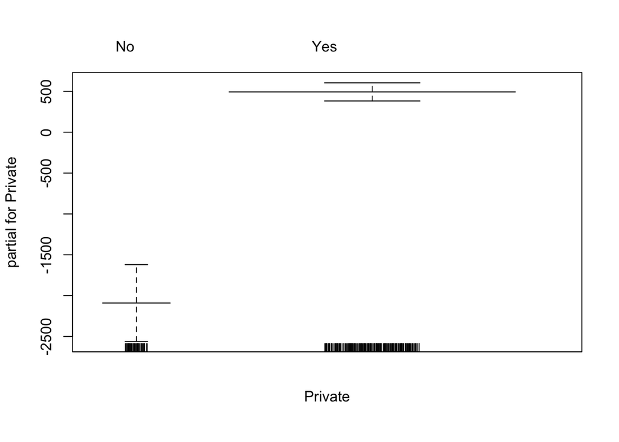

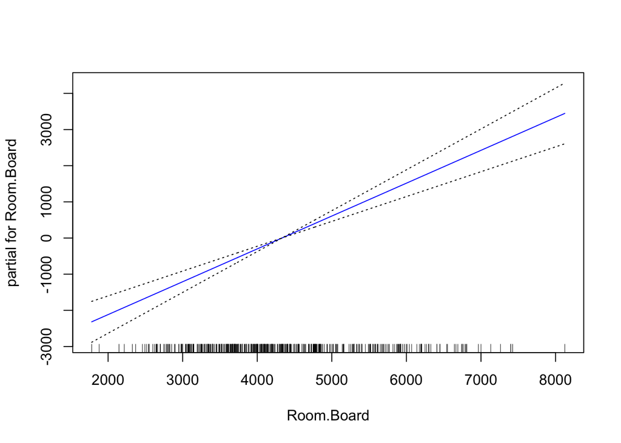

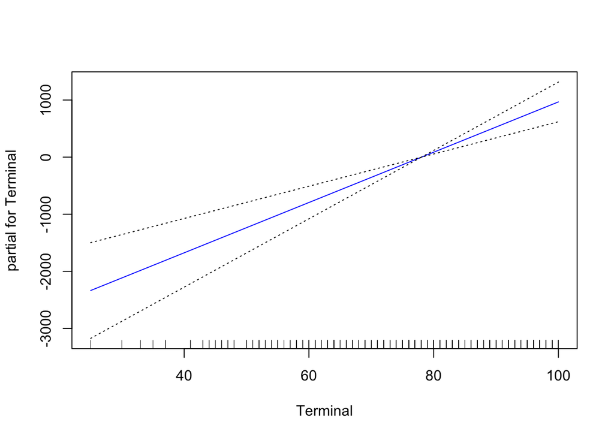

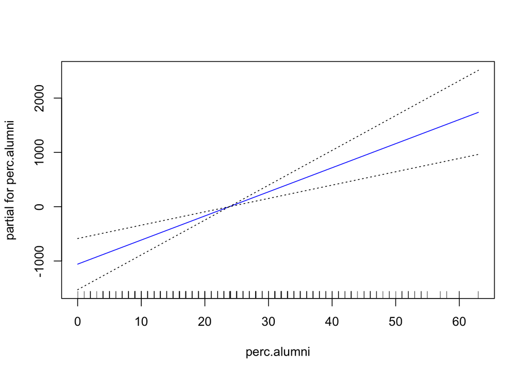

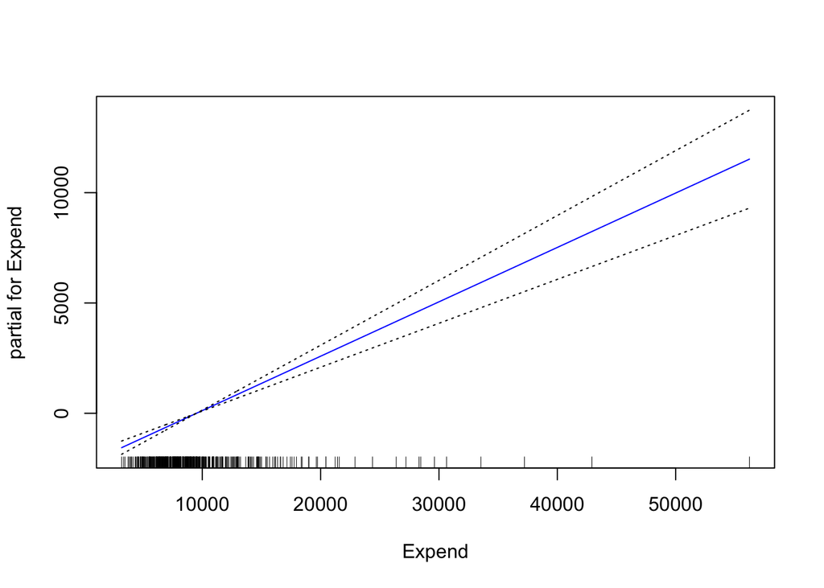

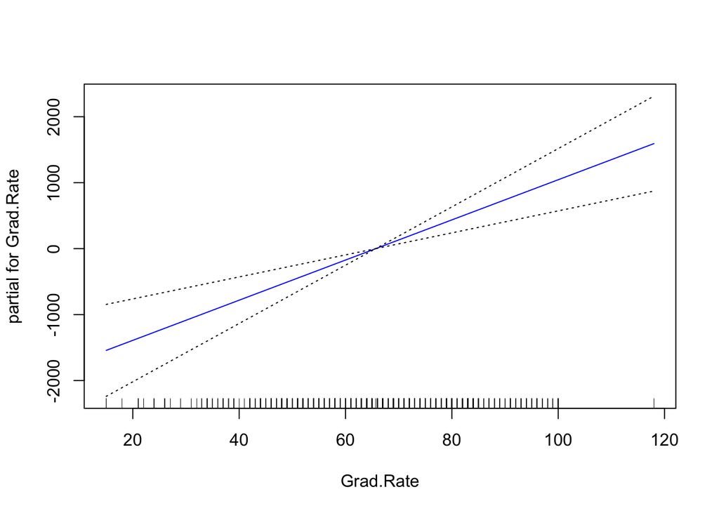

```r
gam <- gam(Outstate ~ Private + Room.Board + Terminal + perc.alumni + Expend + Grad.Rate, data = train)

plot(gam, se = TRUE, col = "blue")
```

3. Evaluate the model obtained on the test set, and explain the results obtained.

```r
calc_rmse <- function(y, y_hat) {
  mse <- calc_mse(y, y_hat)
  return(sqrt(mse))
}

calc_mse <- function(y, y_hat) {
  return(mean((y - y_hat)^2))
}

gam_preds <- predict(gam, test)
gam_rmse <- calc_rmse(test$Outstate, gam_preds)

calc_r2 <- function(y, y_hat) {
  y_bar <- mean(y)
  rss <- sum((y - y_hat)^2)
  tss <- sum((y - y_bar)^2)
  return(1 - (rss / tss))
}

calc_rmse(test$Outstate, gam_preds)
```

```
## [1] 1971.784
```

```r
calc_r2(test$Outstate, gam_preds)
```

```
## [1] 0.7587796
```

4. For which variables, if any, is there evidence of a non-linear relationship with the response?

```r
summary(gam)
```

```
##
## Call: gam(formula = Outstate ~ Private + Room.Board + Terminal + perc.alumni +
##     Expend + Grad.Rate, data = train)
## Deviance Residuals:
##      Min       1Q   Median       3Q      Max
## -8260.48 -1384.85    38.44  1302.41  9828.10
##
## (Dispersion Parameter for gaussian family taken to be 4309509)
##
##     Null Deviance: 7493506291 on 465 degrees of freedom
## Residual Deviance: 1978064681 on 459 degrees of freedom
## AIC: 8450.17
##
## Number of Local Scoring Iterations: 2
##
## Anova for Parametric Effects
##              Df     Sum Sq    Mean Sq F value    Pr(>F)
## Private       1 1838710190 1838710190 426.663 < 2.2e-16 ***
## Room.Board    1 1956527878 1956527878 454.002 < 2.2e-16 ***
## Terminal      1  797100833  797100833 184.963 < 2.2e-16 ***
## perc.alumni   1  353357768  353357768  81.995 < 2.2e-16 ***
## Expend        1  485290451  485290451 112.609 < 2.2e-16 ***
## Grad.Rate     1   84454489   84454489  19.597 1.196e-05 ***
## Residuals   459 1978064681    4309509
## ---
## Signif. codes:  0 '***' 0.001 '**' 0.01 '*' 0.05 '.' 0.1 ' ' 1
```